# Data challenges (Onderwijs voor Professionals)

Missende data en multipele imputatie met `mice`

## Multipele imputatie: het algemene idee

Het hoorcollege van dit deel is beschikbaar via deze link.

The aim of this tutorial is to enhance your understanding of multiple imputation, in general. You will learn how to pool the results of analyses performed on multiply-imputed data, how to approach different types of data and how to avoid the pitfalls researchers may fall into. The main objective is to increase your knowledge and understanding on applications of multiple imputation. No previous experience with `R` is required.

**0. Setup.**

We start by loading the necessary packages and fixing the random seed to allow for our outcomes to be replicable.

```r
library(mice)
library(ggmice)
library(ggplot2)
set.seed(123)
```

**1. Let us multiply impute the missing data in the `nhanes` dataset**

```r
imp <- mice(nhanes)
imp
```

```
Class: mids
Number of multiple imputations:  5
Imputation methods:
  age   bmi   hyp   chl
   "" "pmm" "pmm" "pmm"
PredictorMatrix:
    age bmi hyp chl
age   0   1   1   1
bmi   1   0   1   1
hyp   1   1   0   1
chl   1   1   1   0
```

The object `imp` contains a multiply imputed data set (of class `mids`). It encapsulates all information from imputing the `nhanes` dataset, such as the original data, the imputed values, the number of missing values, number of iterations, and so on.

To obtain an overview of the information stored in the object `imp`, use the `attributes()` function:

```r
attributes(imp)
```

```
$names
 [1] "data"            "imp"             "m"               "where"
 [5] "blocks"          "call"            "nmis"            "method"
 [9] "predictorMatrix" "visitSequence"   "formulas"        "calltype"
[13] "post"            "blots"           "ignore"          "seed"
[17] "iteration"       "lastSeedValue"   "chainMean"       "chainVar"
[21] "loggedEvents"    "version"         "date"

$class
[1] "mids"
```

For example, the original data are stored as

```r
imp$data
```

```
   age  bmi hyp chl
1    1   NA  NA  NA
2    2 22.7   1 187
3    1   NA   1 187
4    3   NA  NA  NA
5    1 20.4   1 113
6    3   NA  NA 184
7    1 22.5   1 118
8    1 30.1   1 187
9    2 22.0   1 238
10   2   NA  NA  NA
11   1   NA  NA  NA
12   2   NA  NA  NA
13   3 21.7   1 206
14   2 28.7   2 204
15   1 29.6   1  NA
16   1   NA  NA  NA
17   3 27.2   2 284
18   2 26.3   2 199
19   1 35.3   1 218
20   3 25.5   2  NA
21   1   NA  NA  NA
22   1 33.2   1 229
23   1 27.5   1 131
24   3 24.9   1  NA
25   2 27.4   1 186
```

and the imputations are stored as

```r
imp$imp
```

```
$age
[1] 1 2 3 4 5
<0 rows> (or 0-length row.names)

$bmi
      1    2    3    4    5
1  22.0 35.3 27.2 29.6 27.2
3  30.1 27.2 30.1 30.1 27.2
4  26.3 25.5 22.7 30.1 24.9
6  27.5 25.5 21.7 24.9 21.7
10 27.4 27.2 30.1 22.0 27.4
11 33.2 22.0 27.2 30.1 35.3
12 27.4 20.4 27.4 27.5 22.0
16 35.3 33.2 26.3 33.2 22.7
21 33.2 22.0 26.3 22.0 29.6
```

[output cut: 24 more lines]

**2. Extract the completed data**

By default, `mice()` calculates five (*m* = 5) imputed data sets. In order to get the third imputed data set, use the `complete()` function

```
 /\     /\
{  `---'  }
{  O   O  }
==>  V <==  No need for mice. This data set is completely observed.
 \  \|/  /
  `-----'
```

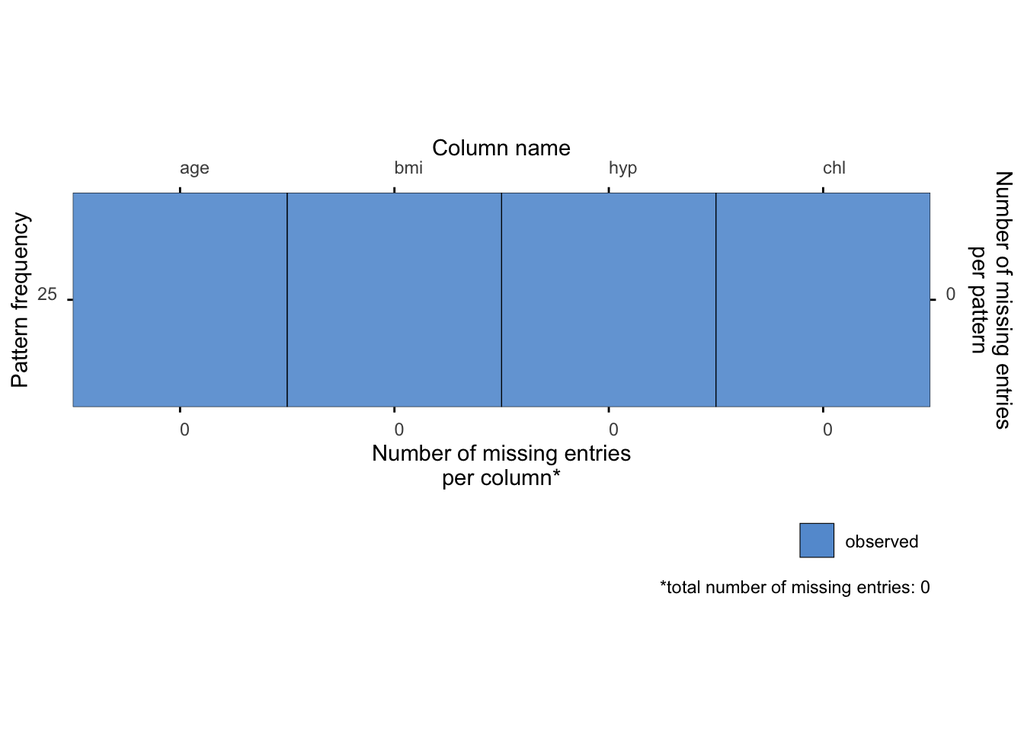

```r
c3 <- complete(imp, 3)
plot_pattern(c3)
```

The collection of the $m$ imputed data sets can be exported by function `complete()` in long, broad and repeated formats.

For example,

```r
c.long <- complete(imp, "long")
c.long
```

```
    age  bmi hyp chl .imp .id
1     1 22.0   1 238    1   1
2     2 22.7   1 187    1   2
3     1 30.1   1 187    1   3
4     3 26.3   2 218    1   4
5     1 20.4   1 113    1   5
6     3 27.5   1 184    1   6
7     1 22.5   1 118    1   7
8     1 30.1   1 187    1   8
9     2 22.0   1 238    1   9
10    2 27.4   1 186    1  10
11    1 33.2   1 187    1  11
12    2 27.4   2 229    1  12
13    3 21.7   1 206    1  13
14    2 28.7   2 204    1  14
```

[output cut: 111 more lines]

and

```r
c.broad <- complete(imp, "broad")
c.broad
```

```
   age.1 bmi.1 hyp.1 chl.1 age.2 bmi.2 hyp.2 chl.2 age.3 bmi.3 hyp.3 chl.3
1      1  22.0     1   238     1  35.3     1   218     1  27.2     1   187
2      2  22.7     1   187     2  22.7     1   187     2  22.7     1   187
3      1  30.1     1   187     1  27.2     1   187     1  30.1     1   187
4      3  26.3     2   218     3  25.5     1   184     3  22.7     1   218
5      1  20.4     1   113     1  20.4     1   113     1  20.4     1   113
6      3  27.5     1   184     3  25.5     2   184     3  21.7     2   184
7      1  22.5     1   118     1  22.5     1   118     1  22.5     1   118
8      1  30.1     1   187     1  30.1     1   187     1  30.1     1   187
9      2  22.0     1   238     2  22.0     1   238     2  22.0     1   238
10     2  27.4     1   186     2  27.2     1   184     2  30.1     1   206
11     1  33.2     1   187     1  22.0     1   238     1  27.2     1   118
12     2  27.4     2   229     2  20.4     1   187     2  27.4     1   206
13     3  21.7     1   206     3  21.7     1   206     3  21.7     1   206
14     2  28.7     2   204     2  28.7     2   204     2  28.7     2   204
```

[output cut: 37 more lines]

are completed data sets in long and broad format, respectively. See `?complete` for more detail.

**3. Vary the number of imputations.**

The number of imputed data sets can be specified by the `m = ...` argument. For example, to create just three imputed data sets, specify

```r
imp <- mice(nhanes, m = 3, print = FALSE)
```

**4. Change the predictor matrix**

The predictor matrix is a square matrix that specifies the variables that are used to impute each incomplete variable. Let us have a look at the predictor matrix that was used

```r
imp$pred
```

```
    age bmi hyp chl
age   0   1   1   1
bmi   1   0   1   1
hyp   1   1   0   1
chl   1   1   1   0
```

```r
ini <- mice(nhanes, maxit = 0, print = FALSE)
pred <- ini$pred
pred
```

```
    age bmi hyp chl
age   0   1   1   1
bmi   1   0   1   1
hyp   1   1   0   1
chl   1   1   1   0
```

The object `pred` contains the predictor matrix from an initial run of `mice` with zero iterations, specified by `maxit = 0`. An equivalent workflow for creating a predictor matrix is with the function `make.predictorMatrix()`.

```r
pred <- make.predictorMatrix(nhanes)
pred
```

```
    age bmi hyp chl
age   0   1   1   1
bmi   1   0   1   1
hyp   1   1   0   1
chl   1   1   1   0
```

Altering the predictor matrix and returning it to the mice algorithm is very simple. For example, the following code removes the variable `hyp` from the set of predictors, but still leaves it to be predicted by the other variables.

```r
pred[ ,"hyp"] <- 0
pred
```

```
    age bmi hyp chl
age   0   1   0   1
bmi   1   0   0   1
hyp   1   1   0   1
chl   1   1   0   0
```

The predictor matrix can be visualized with

```
Ignoring unknown labels:
• colour : ""
```

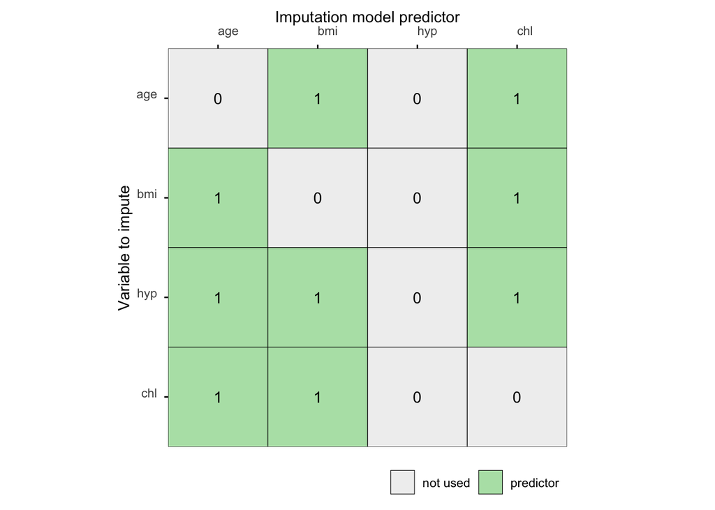

```r
plot_pred(pred)
```

Use your new predictor matrix in `mice()` as follows

```r
imp <- mice(nhanes, pred = pred, print = FALSE)
```

There is a special function called `quickpred()` for a quick selection procedure of predictors, which can be handy for datasets containing many variables. See `?quickpred` for more info. Selecting predictors according to data relations with a minimum correlation of $\rho=.30$ can be done by

```r
pred <- quickpred(nhanes, mincor = .3)
pred
```

```
    age bmi hyp chl
age   0   0   0   0
bmi   1   0   0   1
hyp   1   0   0   1
chl   1   1   1   0
```

For large predictor matrices, it can be useful to export them to Microsoft Excel for easier configuration (e.g. see the `xlsx` package for easy exporting and importing of Excel files).

Visualizing the predictor matrix in `R` is done with

```
Ignoring unknown labels:
• colour : ""
```

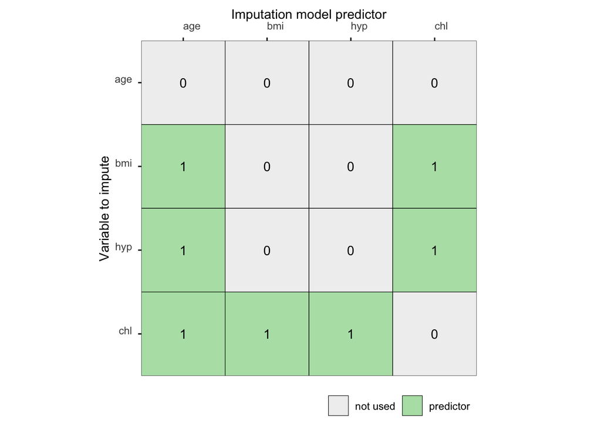

```r
plot_pred(pred)
```

**5. Some diagnostic checking. Use function `ggmice()`.**

Generally, one would prefer for the imputed data to be plausible values, i.e. values that could have been observed if they had not been missing. In order to form an idea about plausibility, one may check the imputations and compare them against the observed values. If we are willing to assume that the data are missing completely at random (MCAR), then the imputations should have the same distribution as the observed data. In general, distributions may be different because the missing data are MAR (or even MNAR). However, very large discrepancies need to be screened. Let us plot the observed and imputed data of `chl` by

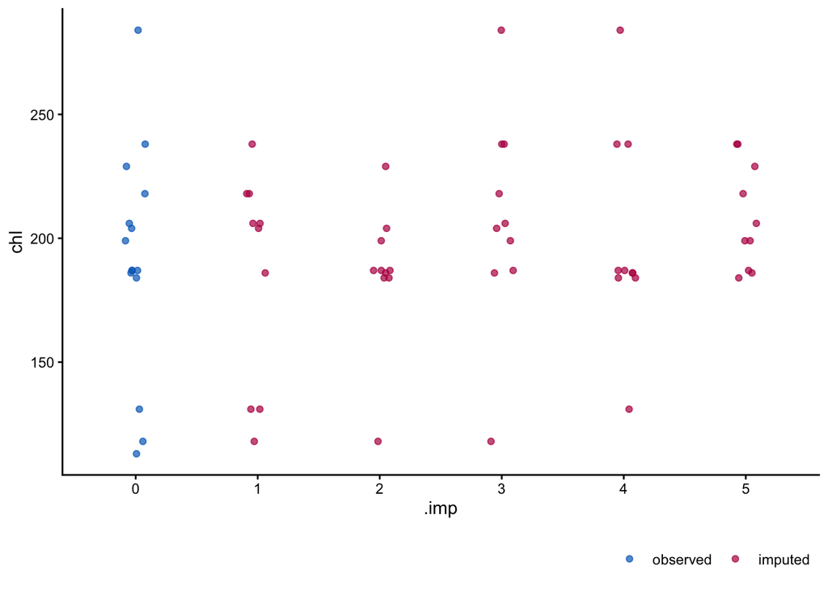

```r
ggmice(imp, aes(.imp, chl)) +
  geom_jitter(width = 0.1, height = 0)
```

The convention is to plot observed data in blue and the imputed data in red. The figure graphs the observed data values of `chl` and the imputed values. Since the PMM method draws imputations from the observed data, imputed values have the same gaps as in the observed data, and are always within the range of the observed data. The figure indicates that the distributions of the imputed and the observed values are similar. The observed data have a particular feature that, for some reason, the data cluster around the value of 187. The imputations reflect this feature, and are close to the data. Under MCAR, univariate distributions of the observed and imputed data are expected to be identical. Under MAR, they can be different, both in location and spread, but their multivariate distribution is assumed to be identical. There are many other ways to look at the imputed data.

The following command creates the graph from the previous step for each of the variables in the dataset.

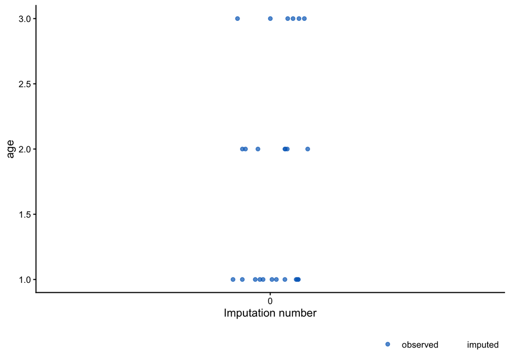

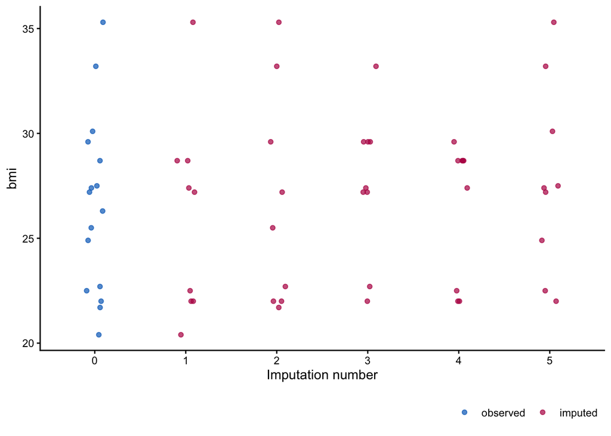

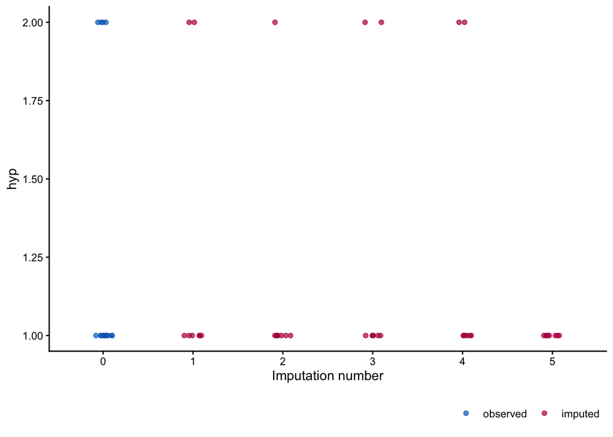

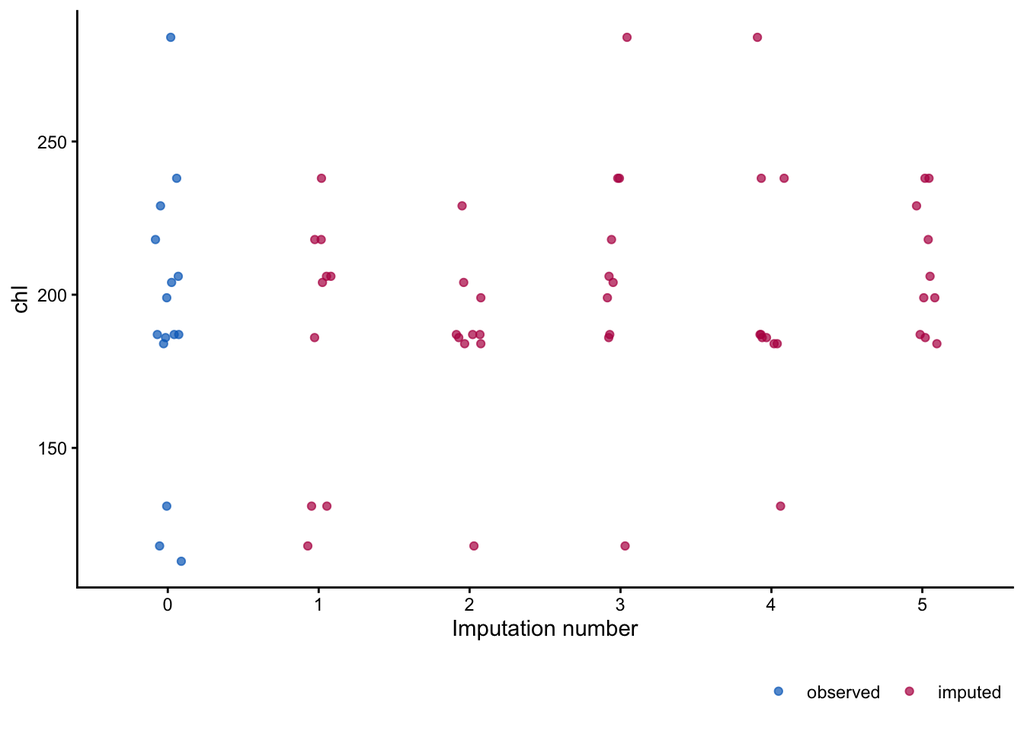

```r
purrr::map(names(imp$data), ~ {
  ggmice(imp, aes(x = .imp, y = .data[[.x]])) +
    geom_jitter(width = 0.1, height = 0) +
    labs(x = "Imputation number")
})
```

**References**

Rubin, D. B. *Multiple imputation for nonresponse in surveys*. John Wiley & Sons, 1987.